# Project: Investigate a Dataset (TMDb movie data)

- Introduction
- Data Wrangling
- Exploratory Data Analysis
- Conclusions

## Introduction

> In this project I have choosed the TMDb move data, this data set contains information about 10,000 movies collected from The Movie Database (TMDb), including user ratings and revenue. Certain columns, like ‘cast’ and ‘genres’, contain multiple values separated by pipe (|) characters. And this will require a special handling to get more valuable data from it.

#### Questions that I intended to explore in this data set are

**1. What kind of properties are associated with movies that have high profit?**

- Does movie popularity have an effect on profit?
- Does movie release year have an effect on profit?
- Does movie release month have an effect on profit?
- Does movie runtime have an effect on profit?
- Does movie adjusted budget have an effect on profit?
- Does movie genre have an effect on profit?

**2. Which movies generes are most popular from year to year?**

```python
# Use this cell to set up import statements for all of the packages that you
#   plan to use.
import pandas as pd
import numpy as np
import matplotlib.pyplot as plt

# Remember to include a 'magic word' so that your visualizations are plotted
#   inline with the notebook. See this page for more:
#   http://ipython.readthedocs.io/en/stable/interactive/magics.html
%matplotlib inline
```

## Data Wrangling

### General Properties

```python
# Load your data and print out a few lines. Perform operations to inspect data
#   types and look for instances of missing or possibly errant data.
movies_df = pd.read_csv('tmdb-movies.csv')
movies_df.head()
```

|  | id | imdb_id | popularity | budget | revenue | original_title | cast | homepage | director | tagline | ... | overview | runtime | genres | production_companies | release_date | vote_count | vote_average | release_year | budget_adj | revenue_adj |
| --- | --- | --- | --- | --- | --- | --- | --- | --- | --- | --- | --- | --- | --- | --- | --- | --- | --- | --- | --- | --- | --- |
| 0 | 135397 | tt0369610 | 32.985763 | 150000000 | 1513528810 | Jurassic World | Chris Pratt\|Bryce Dallas Howard\|Irrfan Khan\|Vi... | http://www.jurassicworld.com/ | Colin Trevorrow | The park is open. | ... | Twenty-two years after the events of Jurassic ... | 124 | Action\|Adventure\|Science Fiction\|Thriller | Universal Studios\|Amblin Entertainment\|Legenda... | 6/9/15 | 5562 | 6.5 | 2015 | 1.379999e+08 | 1.392446e+09 |
| 1 | 76341 | tt1392190 | 28.419936 | 150000000 | 378436354 | Mad Max: Fury Road | Tom Hardy\|Charlize Theron\|Hugh Keays-Byrne\|Nic... | http://www.madmaxmovie.com/ | George Miller | What a Lovely Day. | ... | An apocalyptic story set in the furthest reach... | 120 | Action\|Adventure\|Science Fiction\|Thriller | Village Roadshow Pictures\|Kennedy Miller Produ... | 5/13/15 | 6185 | 7.1 | 2015 | 1.379999e+08 | 3.481613e+08 |
| 2 | 262500 | tt2908446 | 13.112507 | 110000000 | 295238201 | Insurgent | Shailene Woodley\|Theo James\|Kate Winslet\|Ansel... | http://www.thedivergentseries.movie/#insurgent | Robert Schwentke | One Choice Can Destroy You | ... | Beatrice Prior must confront her inner demons ... | 119 | Adventure\|Science Fiction\|Thriller | Summit Entertainment\|Mandeville Films\|Red Wago... | 3/18/15 | 2480 | 6.3 | 2015 | 1.012000e+08 | 2.716190e+08 |
| 3 | 140607 | tt2488496 | 11.173104 | 200000000 | 2068178225 | Star Wars: The Force Awakens | Harrison Ford\|Mark Hamill\|Carrie Fisher\|Adam D... | http://www.starwars.com/films/star-wars-episod... | J.J. Abrams | Every generation has a story. | ... | Thirty years after defeating the Galactic Empi... | 136 | Action\|Adventure\|Science Fiction\|Fantasy | Lucasfilm\|Truenorth Productions\|Bad Robot | 12/15/15 | 5292 | 7.5 | 2015 | 1.839999e+08 | 1.902723e+09 |
| 4 | 168259 | tt2820852 | 9.335014 | 190000000 | 1506249360 | Furious 7 | Vin Diesel\|Paul Walker\|Jason Statham\|Michelle ... | http://www.furious7.com/ | James Wan | Vengeance Hits Home | ... | Deckard Shaw seeks revenge against Dominic Tor... | 137 | Action\|Crime\|Thriller | Universal Pictures\|Original Film\|Media Rights ... | 4/1/15 | 2947 | 7.3 | 2015 | 1.747999e+08 | 1.385749e+09 |

5 rows × 21 columns

```python
movies_df.shape
```

```
(10866, 21)
```

#### Assess the data

```python
movies_df.info()
```

```
<class 'pandas.core.frame.DataFrame'>
RangeIndex: 10866 entries, 0 to 10865
Data columns (total 21 columns):
 #   Column                Non-Null Count  Dtype
---  ------                --------------  -----
 0   id                    10866 non-null  int64
 1   imdb_id               10856 non-null  object
 2   popularity            10866 non-null  float64
 3   budget                10866 non-null  int64
 4   revenue               10866 non-null  int64
 5   original_title        10866 non-null  object
 6   cast                  10790 non-null  object
 7   homepage              2936 non-null   object
 8   director              10822 non-null  object
 9   tagline               8042 non-null   object
 10  keywords              9373 non-null   object
 11  overview              10862 non-null  object
 12  runtime               10866 non-null  int64
 13  genres                10843 non-null  object
 14  production_companies  9836 non-null   object
 15  release_date          10866 non-null  object
 16  vote_count            10866 non-null  int64
 17  vote_average          10866 non-null  float64
 18  release_year          10866 non-null  int64
 19  budget_adj            10866 non-null  float64
 20  revenue_adj           10866 non-null  float64
dtypes: float64(4), int64(6), object(11)
memory usage: 1.7+ MB
```

```python
movies_df.describe()
```

|  | id | popularity | budget | revenue | runtime | vote_count | vote_average | release_year | budget_adj | revenue_adj |
| --- | --- | --- | --- | --- | --- | --- | --- | --- | --- | --- |
| count | 10866.000000 | 10866.000000 | 1.086600e+04 | 1.086600e+04 | 10866.000000 | 10866.000000 | 10866.000000 | 10866.000000 | 1.086600e+04 | 1.086600e+04 |
| mean | 66064.177434 | 0.646441 | 1.462570e+07 | 3.982332e+07 | 102.070863 | 217.389748 | 5.974922 | 2001.322658 | 1.755104e+07 | 5.136436e+07 |
| std | 92130.136561 | 1.000185 | 3.091321e+07 | 1.170035e+08 | 31.381405 | 575.619058 | 0.935142 | 12.812941 | 3.430616e+07 | 1.446325e+08 |
| min | 5.000000 | 0.000065 | 0.000000e+00 | 0.000000e+00 | 0.000000 | 10.000000 | 1.500000 | 1960.000000 | 0.000000e+00 | 0.000000e+00 |
| 25% | 10596.250000 | 0.207583 | 0.000000e+00 | 0.000000e+00 | 90.000000 | 17.000000 | 5.400000 | 1995.000000 | 0.000000e+00 | 0.000000e+00 |
| 50% | 20669.000000 | 0.383856 | 0.000000e+00 | 0.000000e+00 | 99.000000 | 38.000000 | 6.000000 | 2006.000000 | 0.000000e+00 | 0.000000e+00 |
| 75% | 75610.000000 | 0.713817 | 1.500000e+07 | 2.400000e+07 | 111.000000 | 145.750000 | 6.600000 | 2011.000000 | 2.085325e+07 | 3.369710e+07 |
| max | 417859.000000 | 32.985763 | 4.250000e+08 | 2.781506e+09 | 900.000000 | 9767.000000 | 9.200000 | 2015.000000 | 4.250000e+08 | 2.827124e+09 |

**Here we can recognize that budget_adj and revenue_adj hase 0 values**

```python
movies_df.nunique()
```

```
id                      10865
imdb_id                 10855
popularity              10814
budget                    557
revenue                  4702
original_title          10571
cast                    10719
homepage                 2896
director                 5067
tagline                  7997
keywords                 8804
overview                10847
runtime                   247
genres                   2039
production_companies     7445
release_date             5909
vote_count               1289
vote_average               72
release_year               56
budget_adj               2614
revenue_adj              4840
dtype: int64
```

#### Getting columns data types for dtype " object "

```python
def printDataFramObjectTypes(colum_list=[]):
    for col in colum_list:
        print(col, "\t\t" , type(movies_df[col][0]))

printDataFramObjectTypes(['imdb_id','original_title','cast','director','genres','production_companies','release_date'])
```

```
imdb_id 		 <class 'str'>
original_title 		 <class 'str'>
cast 		 <class 'str'>
director 		 <class 'str'>
genres 		 <class 'str'>
production_companies 		 <class 'str'>
release_date 		 <class 'str'>
```

```python
# Check for duplicated
sum(movies_df.duplicated())
```

```
1
```

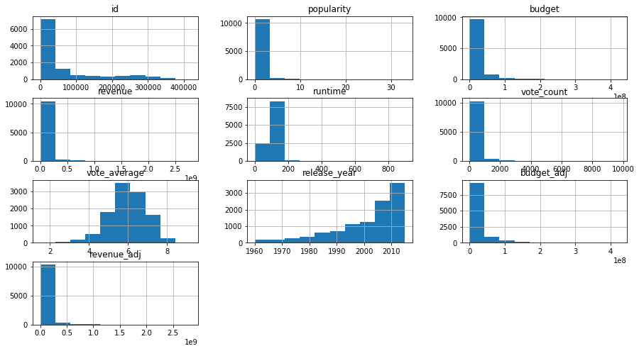

```python
#getting an overview histogram of the dataframe
movies_df.hist(figsize=(15,8));
```

```python
# check genres
movies_df['genres'].head()
```

```
0    Action|Adventure|Science Fiction|Thriller
1    Action|Adventure|Science Fiction|Thriller
2           Adventure|Science Fiction|Thriller
3     Action|Adventure|Science Fiction|Fantasy
4                        Action|Crime|Thriller
Name: genres, dtype: object
```

**generes will need to splited to relate them to movies and be able to make statistics on them**

### Observations from data set

- Revenues and Budgets have 0 values.
- Generes need to be in more structured way.
- Runtime col has 0 values.

### Data Cleaning

#### Steps used in this stage

- Removing unused columns in invistigation such as imdb_id, budget, revenue, homepage, tagline, keywords, overview
- Removing duplicate rows
- Revenues and budgets have 0 values we can drop them
- Chaning release date into date time
- Replacing movies runtime 0 with NAN
- Creaet new dataframe with structred generes data
- Create profit column from revenue_adj and budget_adj
- Rename cloumns and change type

#### Removing unused columns in invistigation such as imdb_id, budget, revenue, homepage, tagline, keywords, overview

```python
#creating a list of col to be deleted
del_col=[ 'imdb_id', 'budget', 'revenue', 'homepage', 'tagline', 'keywords', 'overview']

#deleting the columns
movies_df= movies_df.drop(del_col,1)

#previewing the new dataset
movies_df.head(4)
```

|  | id | popularity | original_title | cast | director | runtime | genres | production_companies | release_date | vote_count | vote_average | release_year | budget_adj | revenue_adj |
| --- | --- | --- | --- | --- | --- | --- | --- | --- | --- | --- | --- | --- | --- | --- |
| 0 | 135397 | 32.985763 | Jurassic World | Chris Pratt\|Bryce Dallas Howard\|Irrfan Khan\|Vi... | Colin Trevorrow | 124 | Action\|Adventure\|Science Fiction\|Thriller | Universal Studios\|Amblin Entertainment\|Legenda... | 6/9/15 | 5562 | 6.5 | 2015 | 1.379999e+08 | 1.392446e+09 |
| 1 | 76341 | 28.419936 | Mad Max: Fury Road | Tom Hardy\|Charlize Theron\|Hugh Keays-Byrne\|Nic... | George Miller | 120 | Action\|Adventure\|Science Fiction\|Thriller | Village Roadshow Pictures\|Kennedy Miller Produ... | 5/13/15 | 6185 | 7.1 | 2015 | 1.379999e+08 | 3.481613e+08 |
| 2 | 262500 | 13.112507 | Insurgent | Shailene Woodley\|Theo James\|Kate Winslet\|Ansel... | Robert Schwentke | 119 | Adventure\|Science Fiction\|Thriller | Summit Entertainment\|Mandeville Films\|Red Wago... | 3/18/15 | 2480 | 6.3 | 2015 | 1.012000e+08 | 2.716190e+08 |
| 3 | 140607 | 11.173104 | Star Wars: The Force Awakens | Harrison Ford\|Mark Hamill\|Carrie Fisher\|Adam D... | J.J. Abrams | 136 | Action\|Adventure\|Science Fiction\|Fantasy | Lucasfilm\|Truenorth Productions\|Bad Robot | 12/15/15 | 5292 | 7.5 | 2015 | 1.839999e+08 | 1.902723e+09 |

#### Removing duplicate rows

```python
movies_df.drop_duplicates(inplace=True)
```

#### Revenues and budgets have 0 values we can drop them

```python
#replacing 0 with NaN of budget_adj and revenue_adj columns in the dataset
cols = ['budget_adj','revenue_adj']
movies_df[cols] = movies_df[cols].replace(0, np.NAN)

# now we can drop null values for runtime
movies_df.dropna(subset = cols, inplace = True)
```

```python
movies_df.shape
```

```
(3854, 14)
```

```python
movies_df.head()
```

|  | id | popularity | original_title | cast | director | runtime | genres | production_companies | release_date | vote_count | vote_average | release_year | budget_adj | revenue_adj |
| --- | --- | --- | --- | --- | --- | --- | --- | --- | --- | --- | --- | --- | --- | --- |
| 0 | 135397 | 32.985763 | Jurassic World | Chris Pratt\|Bryce Dallas Howard\|Irrfan Khan\|Vi... | Colin Trevorrow | 124 | Action\|Adventure\|Science Fiction\|Thriller | Universal Studios\|Amblin Entertainment\|Legenda... | 6/9/15 | 5562 | 6.5 | 2015 | 1.379999e+08 | 1.392446e+09 |
| 1 | 76341 | 28.419936 | Mad Max: Fury Road | Tom Hardy\|Charlize Theron\|Hugh Keays-Byrne\|Nic... | George Miller | 120 | Action\|Adventure\|Science Fiction\|Thriller | Village Roadshow Pictures\|Kennedy Miller Produ... | 5/13/15 | 6185 | 7.1 | 2015 | 1.379999e+08 | 3.481613e+08 |
| 2 | 262500 | 13.112507 | Insurgent | Shailene Woodley\|Theo James\|Kate Winslet\|Ansel... | Robert Schwentke | 119 | Adventure\|Science Fiction\|Thriller | Summit Entertainment\|Mandeville Films\|Red Wago... | 3/18/15 | 2480 | 6.3 | 2015 | 1.012000e+08 | 2.716190e+08 |
| 3 | 140607 | 11.173104 | Star Wars: The Force Awakens | Harrison Ford\|Mark Hamill\|Carrie Fisher\|Adam D... | J.J. Abrams | 136 | Action\|Adventure\|Science Fiction\|Fantasy | Lucasfilm\|Truenorth Productions\|Bad Robot | 12/15/15 | 5292 | 7.5 | 2015 | 1.839999e+08 | 1.902723e+09 |
| 4 | 168259 | 9.335014 | Furious 7 | Vin Diesel\|Paul Walker\|Jason Statham\|Michelle ... | James Wan | 137 | Action\|Crime\|Thriller | Universal Pictures\|Original Film\|Media Rights ... | 4/1/15 | 2947 | 7.3 | 2015 | 1.747999e+08 | 1.385749e+09 |

#### Chaning release date into date time

```python
# converting release_date into datetime object
movies_df['release_date'] = pd.to_datetime(movies_df['release_date'])
```

#### Replacing movies runtime 0 with NAN

```python
#replacing 0 with NaN of runtime column in the dataset
movies_df['runtime'] = movies_df['runtime'].replace(0, np.NAN)
```

```python
sum(movies_df['runtime'].isnull())
```

```
0
```

```python
movies_df[movies_df['runtime'].isnull()]
```

|  | id | popularity | original_title | cast | director | runtime | genres | production_companies | release_date | vote_count | vote_average | release_year | budget_adj | revenue_adj |
| --- | --- | --- | --- | --- | --- | --- | --- | --- | --- | --- | --- | --- | --- | --- |

```python
# now we can drop null values for runtime
movies_df.dropna(subset = ['runtime'], inplace = True)
```

```python
# After discussing the structure of the data and any problems that need to be
#   cleaned, perform those cleaning steps in the second part of this section.
```

#### Creaet new dataframe with structred generes data

```python
movies_df_with_id_as_index = movies_df.set_index('id')
```

```python
# check original data fram not changed
movies_df.head()
```

|  | id | popularity | original_title | cast | director | runtime | genres | production_companies | release_date | vote_count | vote_average | release_year | budget_adj | revenue_adj |
| --- | --- | --- | --- | --- | --- | --- | --- | --- | --- | --- | --- | --- | --- | --- |
| 0 | 135397 | 32.985763 | Jurassic World | Chris Pratt\|Bryce Dallas Howard\|Irrfan Khan\|Vi... | Colin Trevorrow | 124 | Action\|Adventure\|Science Fiction\|Thriller | Universal Studios\|Amblin Entertainment\|Legenda... | 2015-06-09 | 5562 | 6.5 | 2015 | 1.379999e+08 | 1.392446e+09 |
| 1 | 76341 | 28.419936 | Mad Max: Fury Road | Tom Hardy\|Charlize Theron\|Hugh Keays-Byrne\|Nic... | George Miller | 120 | Action\|Adventure\|Science Fiction\|Thriller | Village Roadshow Pictures\|Kennedy Miller Produ... | 2015-05-13 | 6185 | 7.1 | 2015 | 1.379999e+08 | 3.481613e+08 |
| 2 | 262500 | 13.112507 | Insurgent | Shailene Woodley\|Theo James\|Kate Winslet\|Ansel... | Robert Schwentke | 119 | Adventure\|Science Fiction\|Thriller | Summit Entertainment\|Mandeville Films\|Red Wago... | 2015-03-18 | 2480 | 6.3 | 2015 | 1.012000e+08 | 2.716190e+08 |
| 3 | 140607 | 11.173104 | Star Wars: The Force Awakens | Harrison Ford\|Mark Hamill\|Carrie Fisher\|Adam D... | J.J. Abrams | 136 | Action\|Adventure\|Science Fiction\|Fantasy | Lucasfilm\|Truenorth Productions\|Bad Robot | 2015-12-15 | 5292 | 7.5 | 2015 | 1.839999e+08 | 1.902723e+09 |
| 4 | 168259 | 9.335014 | Furious 7 | Vin Diesel\|Paul Walker\|Jason Statham\|Michelle ... | James Wan | 137 | Action\|Crime\|Thriller | Universal Pictures\|Original Film\|Media Rights ... | 2015-04-01 | 2947 | 7.3 | 2015 | 1.747999e+08 | 1.385749e+09 |

```python
# check new data fram with id as index
movies_df_with_id_as_index.head()
```

| id | popularity | original_title | cast | director | runtime | genres | production_companies | release_date | vote_count | vote_average | release_year | budget_adj | revenue_adj |
| --- | --- | --- | --- | --- | --- | --- | --- | --- | --- | --- | --- | --- | --- |
| 135397 | 32.985763 | Jurassic World | Chris Pratt\|Bryce Dallas Howard\|Irrfan Khan\|Vi... | Colin Trevorrow | 124 | Action\|Adventure\|Science Fiction\|Thriller | Universal Studios\|Amblin Entertainment\|Legenda... | 2015-06-09 | 5562 | 6.5 | 2015 | 1.379999e+08 | 1.392446e+09 |
| 76341 | 28.419936 | Mad Max: Fury Road | Tom Hardy\|Charlize Theron\|Hugh Keays-Byrne\|Nic... | George Miller | 120 | Action\|Adventure\|Science Fiction\|Thriller | Village Roadshow Pictures\|Kennedy Miller Produ... | 2015-05-13 | 6185 | 7.1 | 2015 | 1.379999e+08 | 3.481613e+08 |
| 262500 | 13.112507 | Insurgent | Shailene Woodley\|Theo James\|Kate Winslet\|Ansel... | Robert Schwentke | 119 | Adventure\|Science Fiction\|Thriller | Summit Entertainment\|Mandeville Films\|Red Wago... | 2015-03-18 | 2480 | 6.3 | 2015 | 1.012000e+08 | 2.716190e+08 |
| 140607 | 11.173104 | Star Wars: The Force Awakens | Harrison Ford\|Mark Hamill\|Carrie Fisher\|Adam D... | J.J. Abrams | 136 | Action\|Adventure\|Science Fiction\|Fantasy | Lucasfilm\|Truenorth Productions\|Bad Robot | 2015-12-15 | 5292 | 7.5 | 2015 | 1.839999e+08 | 1.902723e+09 |
| 168259 | 9.335014 | Furious 7 | Vin Diesel\|Paul Walker\|Jason Statham\|Michelle ... | James Wan | 137 | Action\|Crime\|Thriller | Universal Pictures\|Original Film\|Media Rights ... | 2015-04-01 | 2947 | 7.3 | 2015 | 1.747999e+08 | 1.385749e+09 |

```python
# Splitting the multiple generes into seperate columns
genres_df = movies_df_with_id_as_index['genres'].str.split("|", expand=True)
# Verifying successful separation
genres_df.head()
```

| id | 0 | 1 | 2 | 3 | 4 |
| --- | --- | --- | --- | --- | --- |
| 135397 | Action | Adventure | Science Fiction | Thriller | None |
| 76341 | Action | Adventure | Science Fiction | Thriller | None |
| 262500 | Adventure | Science Fiction | Thriller | None | None |
| 140607 | Action | Adventure | Science Fiction | Fantasy | None |
| 168259 | Action | Crime | Thriller | None | None |

```python
# Creating a separate dataframe form unique genres records.
genres_df = genres_df.stack()

genres_df = pd.DataFrame(genres_df)
```

```python
genres_df.shape
```

```
(10303, 1)
```

```python
movies_df_with_id_as_index.shape
```

```
(3854, 13)
```

```python
#Renaming the genres column and verifying the genres value count
genres_df.rename(columns={0:'genres_adj'}, inplace=True)
```

```python
genres_df.head()
```

| id |  | genres_adj |
| --- | --- | --- |
| 135397 | 0 | Action |
|  | 1 | Adventure |
|  | 2 | Science Fiction |
|  | 3 | Thriller |
| 76341 | 0 | Action |

```python
# merge tow data fram to get more statistics
genres_df = pd.merge(genres_df,movies_df_with_id_as_index,how='left',left_index=True,right_index=True)
genres_df.head()
```

| id |  | genres_adj | popularity | original_title | cast | director | runtime | genres | production_companies | release_date | vote_count | vote_average | release_year | budget_adj | revenue_adj |
| --- | --- | --- | --- | --- | --- | --- | --- | --- | --- | --- | --- | --- | --- | --- | --- |
| 135397 | 0 | Action | 32.985763 | Jurassic World | Chris Pratt\|Bryce Dallas Howard\|Irrfan Khan\|Vi... | Colin Trevorrow | 124 | Action\|Adventure\|Science Fiction\|Thriller | Universal Studios\|Amblin Entertainment\|Legenda... | 2015-06-09 | 5562 | 6.5 | 2015 | 1.379999e+08 | 1.392446e+09 |
|  | 1 | Adventure | 32.985763 | Jurassic World | Chris Pratt\|Bryce Dallas Howard\|Irrfan Khan\|Vi... | Colin Trevorrow | 124 | Action\|Adventure\|Science Fiction\|Thriller | Universal Studios\|Amblin Entertainment\|Legenda... | 2015-06-09 | 5562 | 6.5 | 2015 | 1.379999e+08 | 1.392446e+09 |
|  | 2 | Science Fiction | 32.985763 | Jurassic World | Chris Pratt\|Bryce Dallas Howard\|Irrfan Khan\|Vi... | Colin Trevorrow | 124 | Action\|Adventure\|Science Fiction\|Thriller | Universal Studios\|Amblin Entertainment\|Legenda... | 2015-06-09 | 5562 | 6.5 | 2015 | 1.379999e+08 | 1.392446e+09 |
|  | 3 | Thriller | 32.985763 | Jurassic World | Chris Pratt\|Bryce Dallas Howard\|Irrfan Khan\|Vi... | Colin Trevorrow | 124 | Action\|Adventure\|Science Fiction\|Thriller | Universal Studios\|Amblin Entertainment\|Legenda... | 2015-06-09 | 5562 | 6.5 | 2015 | 1.379999e+08 | 1.392446e+09 |
| 76341 | 0 | Action | 28.419936 | Mad Max: Fury Road | Tom Hardy\|Charlize Theron\|Hugh Keays-Byrne\|Nic... | George Miller | 120 | Action\|Adventure\|Science Fiction\|Thriller | Village Roadshow Pictures\|Kennedy Miller Produ... | 2015-05-13 | 6185 | 7.1 | 2015 | 1.379999e+08 | 3.481613e+08 |

#### Create profit column from revenue_adj and budget_adj

```python
movies_df['Profit'] = movies_df['revenue_adj'] - movies_df['budget_adj']
genres_df['Profit'] = genres_df['revenue_adj'] - genres_df['budget_adj']
```

```python
movies_df.head()
```

|  | id | popularity | original_title | cast | director | runtime | genres | production_companies | release_date | vote_count | vote_average | release_year | budget_adj | revenue_adj | Profit |
| --- | --- | --- | --- | --- | --- | --- | --- | --- | --- | --- | --- | --- | --- | --- | --- |
| 0 | 135397 | 32.985763 | Jurassic World | Chris Pratt\|Bryce Dallas Howard\|Irrfan Khan\|Vi... | Colin Trevorrow | 124 | Action\|Adventure\|Science Fiction\|Thriller | Universal Studios\|Amblin Entertainment\|Legenda... | 2015-06-09 | 5562 | 6.5 | 2015 | 1.379999e+08 | 1.392446e+09 | 1.254446e+09 |
| 1 | 76341 | 28.419936 | Mad Max: Fury Road | Tom Hardy\|Charlize Theron\|Hugh Keays-Byrne\|Nic... | George Miller | 120 | Action\|Adventure\|Science Fiction\|Thriller | Village Roadshow Pictures\|Kennedy Miller Produ... | 2015-05-13 | 6185 | 7.1 | 2015 | 1.379999e+08 | 3.481613e+08 | 2.101614e+08 |
| 2 | 262500 | 13.112507 | Insurgent | Shailene Woodley\|Theo James\|Kate Winslet\|Ansel... | Robert Schwentke | 119 | Adventure\|Science Fiction\|Thriller | Summit Entertainment\|Mandeville Films\|Red Wago... | 2015-03-18 | 2480 | 6.3 | 2015 | 1.012000e+08 | 2.716190e+08 | 1.704191e+08 |
| 3 | 140607 | 11.173104 | Star Wars: The Force Awakens | Harrison Ford\|Mark Hamill\|Carrie Fisher\|Adam D... | J.J. Abrams | 136 | Action\|Adventure\|Science Fiction\|Fantasy | Lucasfilm\|Truenorth Productions\|Bad Robot | 2015-12-15 | 5292 | 7.5 | 2015 | 1.839999e+08 | 1.902723e+09 | 1.718723e+09 |
| 4 | 168259 | 9.335014 | Furious 7 | Vin Diesel\|Paul Walker\|Jason Statham\|Michelle ... | James Wan | 137 | Action\|Crime\|Thriller | Universal Pictures\|Original Film\|Media Rights ... | 2015-04-01 | 2947 | 7.3 | 2015 | 1.747999e+08 | 1.385749e+09 | 1.210949e+09 |

#### Rename cloumns and change type

```python
# get the release month from data
movies_df['release_date'] = movies_df['release_date'].dt.month
genres_df['release_date'] = genres_df['release_date'].dt.month

# change columns type
movies_df['budget_adj'] = movies_df['budget_adj'].astype(int)
genres_df['budget_adj'] = genres_df['budget_adj'].astype(int)
movies_df['revenue_adj'] = movies_df['revenue_adj'].astype(int)
genres_df['revenue_adj'] = genres_df['revenue_adj'].astype(int)

movies_df['Profit'] = movies_df['Profit'].astype(int)
genres_df['Profit'] = genres_df['Profit'].astype(int)

# rename columns type
movies_df.rename(columns={'release_date':'Months'}, inplace=True)
genres_df.rename(columns={'release_date':'Months'}, inplace=True)
movies_df.rename(columns={'budget_adj':'Budget'}, inplace=True)
genres_df.rename(columns={'budget_adj':'Budget'}, inplace=True)
movies_df.rename(columns={'revenue_adj':'Revenue'}, inplace=True)
genres_df.rename(columns={'revenue_adj':'Revenue'}, inplace=True)
movies_df.rename(columns={'release_year':'Year'}, inplace=True)
genres_df.rename(columns={'release_year':'Year'}, inplace=True)
movies_df.rename(columns={'original_title':'Title'}, inplace=True)
genres_df.rename(columns={'original_title':'Title'}, inplace=True)
```

```python
movies_df.head()
```

|  | id | popularity | Title | cast | director | runtime | genres | production_companies | Months | vote_count | vote_average | Year | Budget | Revenue | Profit |
| --- | --- | --- | --- | --- | --- | --- | --- | --- | --- | --- | --- | --- | --- | --- | --- |
| 0 | 135397 | 32.985763 | Jurassic World | Chris Pratt\|Bryce Dallas Howard\|Irrfan Khan\|Vi... | Colin Trevorrow | 124 | Action\|Adventure\|Science Fiction\|Thriller | Universal Studios\|Amblin Entertainment\|Legenda... | 6 | 5562 | 6.5 | 2015 | 137999939 | 1392445892 | 1254445953 |
| 1 | 76341 | 28.419936 | Mad Max: Fury Road | Tom Hardy\|Charlize Theron\|Hugh Keays-Byrne\|Nic... | George Miller | 120 | Action\|Adventure\|Science Fiction\|Thriller | Village Roadshow Pictures\|Kennedy Miller Produ... | 5 | 6185 | 7.1 | 2015 | 137999939 | 348161292 | 210161353 |
| 2 | 262500 | 13.112507 | Insurgent | Shailene Woodley\|Theo James\|Kate Winslet\|Ansel... | Robert Schwentke | 119 | Adventure\|Science Fiction\|Thriller | Summit Entertainment\|Mandeville Films\|Red Wago... | 3 | 2480 | 6.3 | 2015 | 101199955 | 271619025 | 170419069 |
| 3 | 140607 | 11.173104 | Star Wars: The Force Awakens | Harrison Ford\|Mark Hamill\|Carrie Fisher\|Adam D... | J.J. Abrams | 136 | Action\|Adventure\|Science Fiction\|Fantasy | Lucasfilm\|Truenorth Productions\|Bad Robot | 12 | 5292 | 7.5 | 2015 | 183999919 | 1902723129 | 1718723210 |
| 4 | 168259 | 9.335014 | Furious 7 | Vin Diesel\|Paul Walker\|Jason Statham\|Michelle ... | James Wan | 137 | Action\|Crime\|Thriller | Universal Pictures\|Original Film\|Media Rights ... | 4 | 2947 | 7.3 | 2015 | 174799923 | 1385748801 | 1210948878 |

```python
genres_df.head()
```

| id |  | genres_adj | popularity | Title | cast | director | runtime | genres | production_companies | Months | vote_count | vote_average | Year | Budget | Revenue | Profit |
| --- | --- | --- | --- | --- | --- | --- | --- | --- | --- | --- | --- | --- | --- | --- | --- | --- |
| 135397 | 0 | Action | 32.985763 | Jurassic World | Chris Pratt\|Bryce Dallas Howard\|Irrfan Khan\|Vi... | Colin Trevorrow | 124 | Action\|Adventure\|Science Fiction\|Thriller | Universal Studios\|Amblin Entertainment\|Legenda... | 6 | 5562 | 6.5 | 2015 | 137999939 | 1392445892 | 1254445953 |
|  | 1 | Adventure | 32.985763 | Jurassic World | Chris Pratt\|Bryce Dallas Howard\|Irrfan Khan\|Vi... | Colin Trevorrow | 124 | Action\|Adventure\|Science Fiction\|Thriller | Universal Studios\|Amblin Entertainment\|Legenda... | 6 | 5562 | 6.5 | 2015 | 137999939 | 1392445892 | 1254445953 |
|  | 2 | Science Fiction | 32.985763 | Jurassic World | Chris Pratt\|Bryce Dallas Howard\|Irrfan Khan\|Vi... | Colin Trevorrow | 124 | Action\|Adventure\|Science Fiction\|Thriller | Universal Studios\|Amblin Entertainment\|Legenda... | 6 | 5562 | 6.5 | 2015 | 137999939 | 1392445892 | 1254445953 |
|  | 3 | Thriller | 32.985763 | Jurassic World | Chris Pratt\|Bryce Dallas Howard\|Irrfan Khan\|Vi... | Colin Trevorrow | 124 | Action\|Adventure\|Science Fiction\|Thriller | Universal Studios\|Amblin Entertainment\|Legenda... | 6 | 5562 | 6.5 | 2015 | 137999939 | 1392445892 | 1254445953 |
| 76341 | 0 | Action | 28.419936 | Mad Max: Fury Road | Tom Hardy\|Charlize Theron\|Hugh Keays-Byrne\|Nic... | George Miller | 120 | Action\|Adventure\|Science Fiction\|Thriller | Village Roadshow Pictures\|Kennedy Miller Produ... | 5 | 6185 | 7.1 | 2015 | 137999939 | 348161292 | 210161353 |

## Exploratory Data Analysis

### Research Question 1 (What kind of properties are associated with movies that have high profit?)

- Does movie popularity have an effect on profit?
- Does movie release year have an effect on profit?
- Does movie release month have an effect on profit?
- Does movie runtime have an effect on profit?
- Does movie adjusted budget have an effect on profit?
- Does movie genre have an effect on profit?

## Investigate top 100 profitable movies

```python
top100_movies = movies_df.nlargest(100, 'Profit')
```

```python
top100_movies
```

|  | id | popularity | Title | cast | director | runtime | genres | production_companies | Months | vote_count | vote_average | Year | Budget | Revenue | Profit |
| --- | --- | --- | --- | --- | --- | --- | --- | --- | --- | --- | --- | --- | --- | --- | --- |
| 1329 | 11 | 12.037933 | Star Wars | Mark Hamill\|Harrison Ford\|Carrie Fisher\|Peter ... | George Lucas | 121 | Adventure\|Action\|Science Fiction | Lucasfilm\|Twentieth Century Fox Film Corporation | 3 | 4428 | 7.9 | 1977 | 39575591 | 2789712242 | 2750136650 |
| 1386 | 19995 | 9.432768 | Avatar | Sam Worthington\|Zoe Saldana\|Sigourney Weaver\|S... | James Cameron | 162 | Action\|Adventure\|Fantasy\|Science Fiction | Ingenious Film Partners\|Twentieth Century Fox ... | 12 | 8458 | 7.1 | 2009 | 240886902 | 2827123750 | 2586236847 |
| 5231 | 597 | 4.355219 | Titanic | Kate Winslet\|Leonardo DiCaprio\|Frances Fisher\|... | James Cameron | 194 | Drama\|Romance\|Thriller | Paramount Pictures\|Twentieth Century Fox Film ... | 11 | 4654 | 7.3 | 1997 | 271692064 | 2506405735 | 2234713671 |
| 10594 | 9552 | 2.010733 | The Exorcist | Linda Blair\|Max von Sydow\|Ellen Burstyn\|Jason ... | William Friedkin | 122 | Drama\|Horror\|Thriller | Warner Bros.\|Hoya Productions | 12 | 1113 | 7.2 | 1973 | 39289276 | 2167324901 | 2128035624 |
| 9806 | 578 | 2.563191 | Jaws | Roy Scheider\|Robert Shaw\|Richard Dreyfuss\|Lorr... | Steven Spielberg | 124 | Horror\|Thriller\|Adventure | Universal Pictures\|Zanuck/Brown Productions | 6 | 1415 | 7.3 | 1975 | 28362748 | 1907005841 | 1878643093 |
| ... | ... | ... | ... | ... | ... | ... | ... | ... | ... | ... | ... | ... | ... | ... | ... |
| 7887 | 90 | 2.108338 | Beverly Hills Cop | Eddie Murphy\|Judge Reinhold\|John Ashton\|Ronny ... | Martin Brest | 105 | Action\|Comedy\|Crime | Paramount Pictures\|Eddie Murphy Productions | 11 | 535 | 6.5 | 1984 | 31485630 | 664053942 | 632568312 |
| 1959 | 24021 | 1.546212 | The Twilight Saga: Eclipse | Kristen Stewart\|Robert Pattinson\|Taylor Lautne... | David Slade | 124 | Adventure\|Fantasy\|Drama\|Romance | Summit Entertainment\|Maverick Films\|Imprint En... | 6 | 1331 | 5.9 | 2010 | 68000000 | 698491347 | 630491347 |
| 6560 | 950 | 3.145562 | Ice Age: The Meltdown | Ray Romano\|John Leguizamo\|Denis Leary\|Queen La... | Carlos Saldanha | 91 | Animation\|Family\|Comedy\|Adventure | Blue Sky Studios\|Twentieth Century Fox Animation | 3 | 1775 | 6.4 | 2006 | 86533532 | 714919257 | 628385724 |
| 10225 | 788 | 1.732126 | Mrs. Doubtfire | Robin Williams\|Sally Field\|Pierce Brosnan\|Harv... | Chris Columbus | 125 | Comedy\|Drama\|Family | Twentieth Century Fox Film Corporation\|Blue Wolf | 11 | 809 | 6.9 | 1993 | 37736749 | 666108255 | 628371506 |
| 9 | 150540 | 6.326804 | Inside Out | Amy Poehler\|Phyllis Smith\|Richard Kind\|Bill Ha... | Pete Docter | 94 | Comedy\|Animation\|Family | Walt Disney Pictures\|Pixar Animation Studios\|W... | 6 | 3935 | 8.0 | 2015 | 160999929 | 785411574 | 624411645 |

100 rows × 15 columns

### Check the effect of popularity on the profit

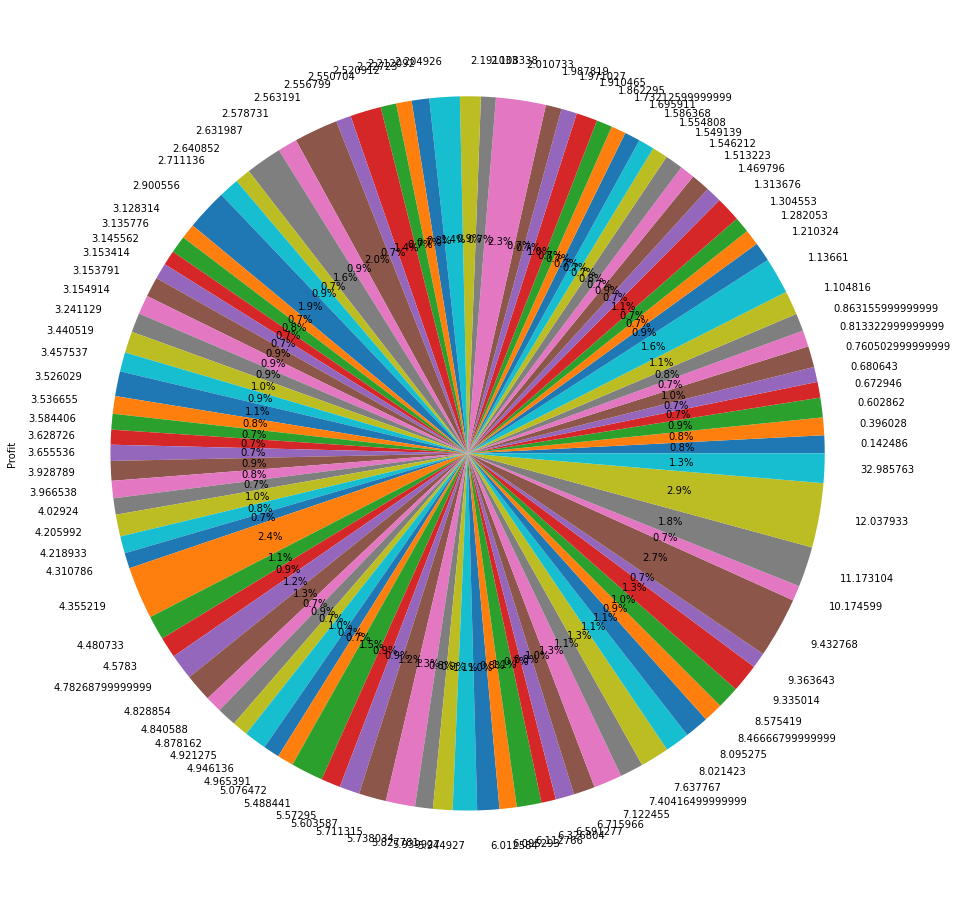

```python
top100_movies.groupby(['popularity'])['Profit'].mean().plot.pie(y='Profit',autopct='%1.1f%%', startangle=0, figsize=(16, 20))
```

### Check the effect of release year on the profit

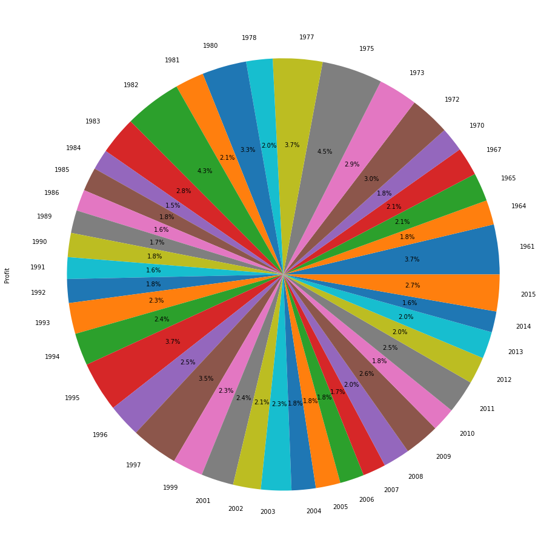

```python
top100_movies.groupby(['Year'])['Profit'].mean().plot.pie(y='Profit',autopct='%1.1f%%', startangle=0, figsize=(16, 20))
```

### Check the effect of release moths on the profit

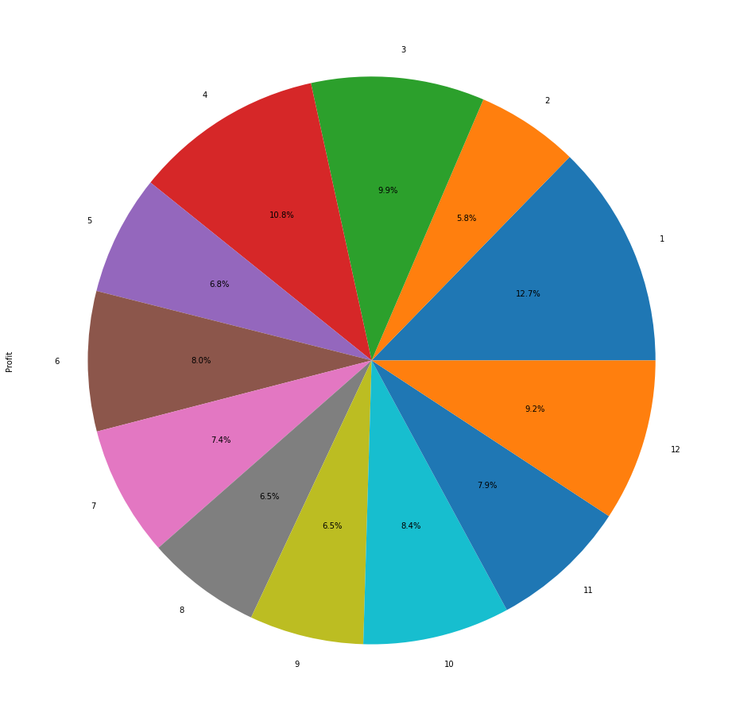

```python
top100_movies.groupby(['Months'])['Profit'].mean().plot.pie(y='Profit',autopct='%1.1f%%', startangle=0, figsize=(16, 20))
```